# Trabajo en clase # 1

Jose Aguilar, Eilyn Salazar, Crisia Piedra

May 15, 2020

# Fase de entendimiento del negocio

## Determinar los objetivos de negocio

### Objetivos de negocio

1. Incrementar las ventas enfocándose en los mejores clientes.
2. Mejorar la disponibilidad de inventarios para satisfacer la demanda de productos.

### Criterios de éxito (en términos de negocio)

1. Identificar los 3 segmentos de mercado más rentables para la empresa a fin de orientar la estrategia de ventas.
2. Mejorar las estimaciones de ventas mensuales un 20% de su valor real.

## Evaluación de la situación actual

Actualmente la compañía XYZ no cuenta con controles para estimar la demanda de los productos que ofrece a través de sus diferentes cadenas minoristas, esto produce que en ocasiones el inventario disponible sea insuficiente para cierto tipo de productos y en otras ocasiones haya exceso de existencias de otros, por esta razón desea optimizar la gestión de sus inventarios a partir de la información histórica disponible sobre las ventas de los diferentes productos que se comercializan.

Por otra parte, el departamento de mercadeo de la empresa desea optimizar su presupuesto enfocando sus esfuerzos en los clientes que son más rentables para la compañía para esto está considerando crear un programa de fidelidad, sin embargo no cuenta con información sobre el perfil de sus mejores clientes.

### Inventario de recursos(datos, personal, TI)

#### Datos

- Datos de ventas históricos de un año.

#### Personal

- 1 patrocinador del proyecto representando la gerencia.
- 1 experto del área de mercadeo para apoyar la estrategia del negocio.
- 1 analista de datos con conocimiento de los sistemas y fuentes de datos.
- 1 desarrollador.

#### TI

Un ambiente virtualizado en la nube con las siguientes características. * OS: Window Server 2016 * RAM: 32 GB * CPU: @2.4 GHz 2.39 GHz (8 processors)

#### Software

1. R y RStudio: Para análisis de datos.
2. MySQL y MySQL Workbench: Fuentes, almacenamiento de datos y herramientas de modelado y consulta.
3. Tableau: Visualización de datos
4. Notepad++ y Visual Studio Code: Desarrollo y revisión de logs de sistema.

### Requerimientos

#### Seguridad

- Solo la gerencia de mercadeo y la gerencia general tendrá acceso a los resultados de la investigación realizada.

#### Legales /Confidencialidad

- Considerando las políticas de confidencialidad y el manejo de los datos personales de los clientes, este proyecto no debe hacer uso de datos personales para su análisis.

#### Implementación y mantenimiento

- Considerando que se utilizará un ambiente virtualizado en la nube, se requiere el uso de VPNs para el acceso al área de desarrollo.
- Todos los equipos utilizados para el análisis deben contar con los parches de sistema operativo y antivirus actualizado.
- El despliegue de los resultados del modelo, y reportes generados se realizará mediante el uso de la herramienta Tableau.

#### Cronograma

- Se estima que la duración del proyecto no podrá exceder más de 1 mes.

### Supuestos

- Se cuenta con acceso a datos de ventas de 1 año.
- La compañía cuenta con los recursos técnicos para satisfacer los requerimientos técnicos del proyecto.
- El proyecto cuenta con la aprobación del negocio y el personal capacitado para ser desarrollado.

### Restricciones

- Solo se cuenta con 1 año de datos históricos.
- La información de clientes es limitada por motivos de privacidad.
- Ausencia de información sobre las categorías de cada producto.

### Riesgos y contingencias

```r
atributos<-read.csv('riesgos.csv', sep = ',',dec = '.')
kable(atributos[,0:3],caption = "Riesgos y Contingencias")%>%
kable_styling(bootstrap_options = c("striped", "hover"))
```

Riesgos y Contingencias

| Tipo.de.Riesgo | Riesgo | Estrategia.de.Contingencia |
| --- | --- | --- |
| Riesgos de Negocio | Cambios en el ambiente de negocio que sean contrarios al objetivo del proyecto. | Involucrar a las diferentes áreas e involucrados de la compañía en la toma de decisiones y presentación de avances del proyecto, para hacer los cambios o adaptaciones requeridos según la necesidad del… |
| Riesgos Organizacionales | Cambios organizacionales | Desarrollo de planes de continuidad del negocio que permitan documentar todo el proceso de desarrollo, documentar roles, responsabilidades y tareas para el manejo de personal de respaldo o backups en … |
|  | Salida de involucrados clave para la compañía. |  |
| Riesgos Financieros | Incremento en el costo estimado del proyecto. | Creación de un presupuesto extraordinario para el manejo de imprevistos financieros durante el proyecto. |
| Riesgos Técnicos | Herramientas seleccionadas para la implementación no cumplen las expectativas | Previo a la fase de implementación y desarrollo realizar una comparación de las herramientas a utilizar. |
| Riesgos de los datos | Datos limitados a 1 año de ventas | Diseñar una estrategia de mantenimiento de los datos, para la evaluación de los objetivos de forma anual. |
|  | Ausencia de datos de nuevos productos del mercado | Diseñar en conjunto con el analista de datos una estrategia de sincronización de los datos periódica para la inclusión de nuevos productos |

### Beneficios

- Reducción de gastos por almacenamiento de inventarios y evitar compras innecesarias.
- Mejora en la tasa de retención de clientes
- Incremento en las ganancias gracias a la mayor disponibilidad de inventario para los productos más vendidos.

## Determinar los objetivos de minería de datos

### Objetivos de minería de datos

- Identificar segmentos de mercados minoristas a partir de las ventas.
- Determinar los 3 segmentos de mercado que generan más ingresos.
- Predecir las ventas mensuales por producto a partir de los datos históricos.

### Criterios de éxito (desde la perspectiva de minería de datos)

1. Identificar 3 clústeres de datos que permitan agrupar los diferentes clientes de la compañía pasado en su perfil.
2. Evaluar la precisión del modelo de predicción a fin de validar que la predicción se encuentre dentro de un 20% de las ventas reales.

## Plan del proyecto

### Evaluación inicial de herramientas y técnicas

Para el desarrollo de este proyecto se utilizará el lenguaje de programación R, y la herramienta RStudio a fin de realizar al proceso de exploración de los datos e identificar las librerías y técnicas de minería de datos más apropiadas para la realización del mismo.

Para el cumplimiento de los objetivos de mineria se utilizaran las técnicas de clustering K-means, y kmedoids, de igual manera para la predicción de las ventas se usara regresión lineal simple y múltiple.

### Plan del proyecto

```r
atributos<-read.csv('plan_proyecto.csv', sep = ',',dec = '.',encoding = "UTF-8")
kable(atributos[,0:5],caption = "Plan de Proyecto")%>%
kable_styling(bootstrap_options = c("striped", "hover"))
```

Plan de Proyecto

Fases

Actividades

Riesgos

Contingencias

Recurso

Entendimiento del negocio

1. Determinar los objetivos del negocio
2. Evaluación de la situación
3. Determinar los objetivos de minería de datos
4. Generar el plan de proyecto.

Falta de disponibilidad de los involucrados. Objetivos definidos no alineados con las necesidades del negocio.

Validación de los objetivos con la gerencia ejecutiva de la compañía. Coordinación a través de conferencias y emails para establecer la fecha de inicio del proyecto. Milestones. Creación de un project roster para la ubicación de los involucrados y sus backups en caso de ser necesario.

Patrocinador Experto en la gerencia de mercadeo

Entendimiento de los datos

1. Recopilación inicial de datos

Describir los datos

Explorar los datos

Verificar la calidad de los datos

Ausencia de productos lanzados recientemente al mercado. Falta de conocimiento de negocio por parte del analista.

En conjunto con el analista de datos, realizar un proceso de verificación y recolección de los datos más recientes en el mercado. Trabajar de la mano con el experto en la gerencia de mercadeo y otros involucrados expertos en el manejo de los datos.

Experto en la gerencia de mercadeo Analista de datos Desarrollador

Preparación de los datos

1. Selección de los datos.

Limpiar los datos.

Construcción de datos

Integrar los datos

Ausencia de valores en múltiples columnas. Determinar las variables que analizar como parte del problema a resolver

Determinar la mejor técnica de imputación de datos, en conjunto con la gerencia de mercadeo. Uso de técnicas como análisis de correlación, análisis de componentes principales para identificar las variables más relevantes para el análisis.

Experto en la gerencia de mercadeo Analista de datos Desarrollador

Modelado

1. Seleccionar la técnica de modelado

Generar diseño de testing

Construir el modelo

Evaluar el modelo

Mal diseño en la implementación del modelo Las técnicas de minería seleccionados no proveen los resultados esperados La duración en la ejecución de los modelos y su entrenamiento tarda más de lo estimado

Uso de múltiples modelos al aplicar una misma técnica de minería. Uso de múltiples técnicas de minería.

Analista de datos Desarrollador

Evaluación

1. Evaluar los Resultados

Revisión del proceso

Determinar Pasos a Seguir

Insatisfacción de los involucrados con los resultados del proyecto

Aumento de las capacidades computacionales de los equipos en los que se realiza el proceso de entrenamiento. Replanteamiento de las metas y objetivos de la investigación con los involucrados del proyecto, añadiendo nuevas variables/datos adicionales

Experto en la gerencia de mercadeo Analista de datos Desarrollador

Implementación (Deployment)

1. Plan de despliegue

Plan de Monitoreo y mantenimiento

Producción del reporte final

Revisión del proyecto

Aumento en el costo de los recursos técnicos disponibles. Variación en el alcance del proyecto.

Comparación de proveedores que ofrecen servicios en la nube y se adecuen a las necesidades del proyecto. Establecimiento de una condición de cierre del proyecto y creación de un plan de administración para nuevas fases

Analista de datos Desarrollador

# Fase de entendimiento de los datos

## Recopilación inicial de datos

### Lista de datasets requeridos

Para el desarrollo de este trabajo se hará uso del conjunto de datos“Online Retail”. Este es un conjunto de datos transnacionales que contiene todas las transacciones que ocurren entre el 12/01/2010 y el 12/09/2011 para un minorista en línea registrado en el Reino Unido y sin tienda. La compañía vende principalmente regalos únicos para toda ocasión.

#### Ubicación de los datasets

Este conjunto de datos se encuentra disponible en el Machine Learning Repository a través del siguiente url.

#### Método de acceso

El conjunto de datos puede ser descargado en formato .xlsx a través del siguiente link http://archive.ics.uci.edu/ml/machine-learning-databases/00352/

#### Descripción de los datos

```r
atributos<-read.csv('atributos.csv', sep = ',',dec = '.')
kable(atributos[,0:3],caption = "Descripción de atributos")%>%
kable_styling(bootstrap_options = c("striped", "hover"))
```

Descripción de atributos

| Variable | Descripción | Tipo |
| --- | --- | --- |
| InvoiceNo | Número de factura Nominal; un número integral de 6 dígitos asignado exclusivamente a cada transacción. Si este código comienza con la letra ‘c’; indica una cancelación. | Cualitativa Nominal (Alfanumérico) |
| StockCode | Código de producto (artículo). Nominal; un número integral de 5 dígitos asignado exclusivamente a cada producto distinto. | Cualitativa Nominal (Alfanumérico) |
| Description | Nombre del producto (artículo). Nominal. | Cualitativa Nominal (Alfanumérico) |
| Quantity | Las cantidades de cada producto (artículo) por transacción. Numérico. | Cuantitativa Continua (Numérico) |
| InvoiceDate | Fecha y hora de inicio. Numérico; el día y la hora en que se generó cada transacción. | Cuantitativa Discreta (Fecha) |
| UnitPrice | Precio unitario. Numérico; precio del producto por unidad en libras esterlinas. | Cuantitativa Continua (Numérico) |
| CustomerID | Número de cliente. Nominal; un número integral de 5 dígitos asignado exclusivamente a cada cliente. | Cualitativa Nominal (Alfanumérico) |
| Country | Nombre del país. Nominal; el nombre del país donde reside cada cliente. | Cualitativa Nominal (Alfanumérico) |

### Exploración de los datos

Se aplicó la función summary para la obtención de las estadísticas básicas de cada variable del conjunto de datos. Por medio de este análisis es posible observar elementos interesantes como los valores mínimos y máximos de las cantidades.

```r
retail<-read_excel("Online Retail.xlsx")
summary(retail)
```

```
##   InvoiceNo          StockCode         Description
##  Length:541909      Length:541909      Length:541909
##  Class :character   Class :character   Class :character
##  Mode  :character   Mode  :character   Mode  :character
##
##
##
##
##     Quantity          InvoiceDate                    UnitPrice
##  Min.   :-80995.00   Min.   :2010-12-01 08:26:00   Min.   :-11062.06
##  1st Qu.:     1.00   1st Qu.:2011-03-28 11:34:00   1st Qu.:     1.25
##  Median :     3.00   Median :2011-07-19 17:17:00   Median :     2.08
##  Mean   :     9.55   Mean   :2011-07-04 13:34:57   Mean   :     4.61
##  3rd Qu.:    10.00   3rd Qu.:2011-10-19 11:27:00   3rd Qu.:     4.13
##  Max.   : 80995.00   Max.   :2011-12-09 12:50:00   Max.   : 38970.00
##
##    CustomerID       Country
##  Min.   :12346    Length:541909
##  1st Qu.:13953    Class :character
##  Median :15152    Mode  :character
##  Mean   :15288
##  3rd Qu.:16791
##  Max.   :18287
##  NA's   :135080
```

En el summary podemos ver algunas cosas interesantes, como por ejempo:

- Se identifican posibles valores default para variables como quantity con -80995.00 - es un valor irreal para una cantidad, por lo que es posible que sea el valor por defecto de este campo, y se obtiene como el valor mínimo en ese campo.
- Otro de los detalles que logra observarse es como variables como CustomerID y Description tienen valores NA.

Nota: En el caso de description es posible observar líneas en blanco al revisar las observaciones.

Para efectos de la tarea se le dará prioridad a los siguientes 5 campos:

- InvoiceNo: Sera utilizado para agrupar las compras.
- Quantity: Sera utilizado para determinar el conjunto de productos mas vendidos.
- UnitPrice: Sera utilizado para determinar, junto con Quantity. las ventas a predecir.
- CustomerID: Sera utilizado para identificar los clientes que seran agrupados.
- Total: Campo derivado (ver siguiente sección) que facilitará los calculos de las ventas.

#### Compras de clientes

De estos datos y basado en estas observaciones prelminares es posible crear algunos campos adicionales que pueden ayudar a la hora de manipularlos. Para inciar, vamos a crear estos dos campos adicionales:

| Campo | Descripción | Tipo |
| --- | --- | --- |
| Total | Total de la compra del producto, resultado de multiplicar UnitPrice por Quantity | Numérico |
| InvoiceDay | Fecha de la compra sin la hora para sumarizar por día las compras | Fecha |

```r
retail$Total <- retail$UnitPrice * retail$Quantity
retail$InvoiceDay <- as.Date(format(retail$InvoiceDate,"%Y-%m-%d"))
```

Ademas podemos observar que existen variables que son actualmente hileras (strings) o numeros pero en realidad representan un factor, por lo que se realizan las siguientes conversiones para estas columnas:

| Campo | Conversión | Nuevo Tipo |
| --- | --- | --- |
| StockCode | Convertirlo a un factor | Factor |
| Description | Convertirlo a un factor | Factor |
| Country | Convertirlo a un factor | Factor |
| CustomerID | Convertirlo a un factor | Factor |

```r
retail$StockCode <- as.factor(retail$StockCode)
retail$Description <- as.factor(retail$Description)
retail$Country <- as.factor(retail$Country)
retail$CustomerID <- as.factor(retail$CustomerID)
```

Podemos revisar algunas de estas variables y como se relacionan. Por ejemplo, en el siguiente gráfico se muestra el resultado de la multiplicación de las variables *UnitPrice* y *Quantity* (variable *Total*) agrupadas por cliente, y se muestran las compras totales de los 10 primeros clientes de la tabla:

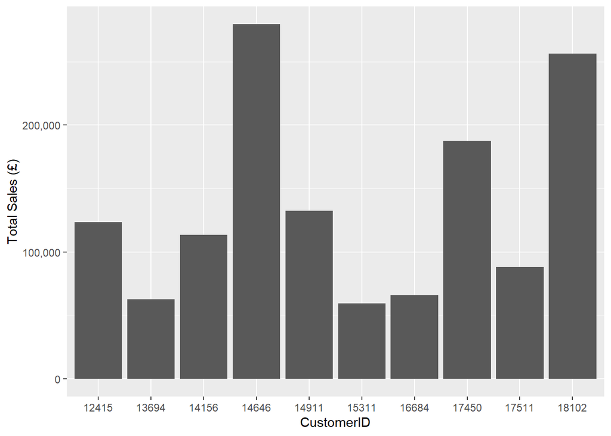

```r
por_cliente <- retail[!is.na(retail$CustomerID),] %>%
  group_by(CustomerID) %>%
  summarise_at(vars(Total),funs(sum(.))) %>%
  arrange(desc(Total))
pp<-ggplot(data=head(por_cliente,10), aes(x=CustomerID,y=Total)) +
  geom_bar(stat="identity") +
  scale_y_continuous(name="Total Sales (£)", labels = scales::comma)
pp
```

A través del customerID podemos ver las compras totales del cliente por ejemplo el cliente 14646 realizó compras totales por un monto de ￡279489 en 721 productos diferentes.

Podemos ver que productos compra:

```r
#Agrupamos por productos:
un_cliente_productos <- subset(retail, CustomerID==14646) %>%
  group_by(StockCode,Description) %>%
  summarise_at(vars(Quantity,Total),list(~sum(.))) %>%
  arrange(desc(Total))
un_cliente_totales<-sum(un_cliente_productos$Total)
un_cliente_productos_diferentes<-nrow(un_cliente_productos)
```

Las compras totales del cliente son:

```r
print(un_cliente_totales)
```

```
## [1] 279489
```

en la siguiente cantidad de productos:

```r
print(un_cliente_productos_diferentes)
```

```
## [1] 721
```

La siguiente tabla es una muestra de los productos que adquirió, la cantidad que adquirió y el total de la venta:

```r
kable(head(un_cliente_productos,10),"html", booktabs = T)%>%
kable_styling(latex_options = "striped")
```

| StockCode | Description | Quantity | Total |
| --- | --- | --- | --- |
| 23084 | RABBIT NIGHT LIGHT | 4801 | 9568.48 |
| 22326 | ROUND SNACK BOXES SET OF4 WOODLAND | 3120 | 7956.00 |
| 22629 | SPACEBOY LUNCH BOX | 4492 | 7415.40 |
| 22630 | DOLLY GIRL LUNCH BOX | 4096 | 6758.40 |
| 22328 | ROUND SNACK BOXES SET OF 4 FRUITS | 1584 | 4039.20 |
| 85099B | JUMBO BAG RED RETROSPOT | 2000 | 3468.00 |
| 21731 | RED TOADSTOOL LED NIGHT LIGHT | 2376 | 3459.60 |
| 22423 | REGENCY CAKESTAND 3 TIER | 288 | 3153.60 |
| 22243 | 5 HOOK HANGER RED MAGIC TOADSTOOL | 2016 | 2923.20 |
| 20712 | JUMBO BAG WOODLAND ANIMALS | 1500 | 2629.00 |

Podemos ver que algunos clientes compran grandes cantidades - por ejemplo en este caso, el cliente compró 4801 unidades del producto RABBIT NIGHT LIGHT. Esto nos hace pensar que algunas de las cantidades grandes vistas anterioremente no son anómalas.

Los siguientes gráficos muestran el comportamiento de las ventas en el tiempo, así como la agrupación por país.

Para observar las ventas por día, utilizamos la variable InvoiceDay, con el fin de eliminar la hora de la venta que no es de interés para este análisis.

```r
invoices <- retail %>%
  group_by(InvoiceDay) %>%
  summarise_at(vars(Total),funs(sum(.)))
kable(head(invoices,10),"html", booktabs = T)%>%
  kable_styling(latex_options = "striped")
```

| InvoiceDay | Total |
| --- | --- |
| 2010-12-01 | 58635.56 |
| 2010-12-02 | 46207.28 |
| 2010-12-03 | 45620.46 |
| 2010-12-05 | 31383.95 |
| 2010-12-06 | 53860.18 |
| 2010-12-07 | 45059.05 |
| 2010-12-08 | 44189.84 |
| 2010-12-09 | 52532.13 |
| 2010-12-10 | 57404.91 |
| 2010-12-12 | 17240.92 |

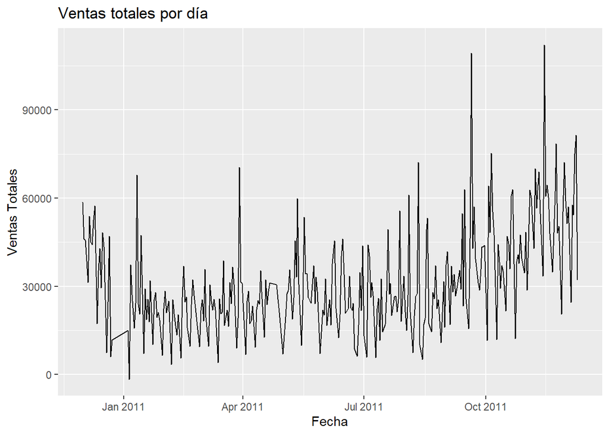

```r
p <- ggplot(invoices, aes(x=InvoiceDay, y=Total)) +
  geom_line() +
  xlab("Fecha") +
  ylab("Ventas Totales") +
  ggtitle("Ventas totales por día")
p
```

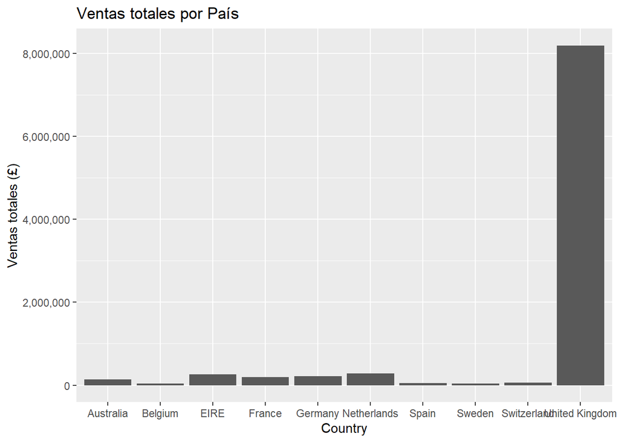

```r
por_pais <- retail %>%
  group_by(Country) %>%
  summarise_at(vars(Total),funs(sum(.))) %>%
  arrange(desc(Total))
pp<-ggplot(data=head(por_pais,10), aes(x=Country,y=Total)) +
  geom_bar(stat="identity") +
  scale_y_continuous(name="Ventas totales (£)", labels = scales::comma) +
  ggtitle("Ventas totales por País")
pp
```

Y podemos ademas observar las cantidades de las ventas por país:

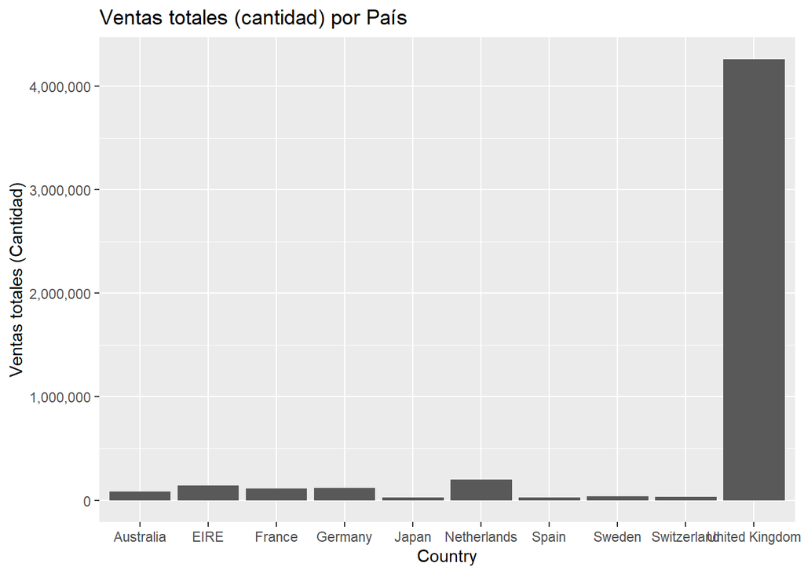

```r
por_cantidad <- retail %>%
  group_by(Country) %>%
  summarise_at(vars(Quantity),funs(sum(.))) %>%
  arrange(desc(Quantity))
pp<-ggplot(data=head(por_cantidad,10), aes(x=Country,y=Quantity)) +
  geom_bar(stat="identity") +
  scale_y_continuous(name="Ventas totales (Cantidad)", labels = scales::comma) +
  ggtitle("Ventas totales (cantidad) por País")
pp
```

### Calidad de los datos

Uno de los problemas de calidad detectados es el gran número de observaciones en donde el CustomerID tiene un valor NA, es decir no se tiene la información de cuáles fueron los clientes que realizaron las compras, lo cual puede influir en el análisis a realizar al no contar con esta información.

```r
sum(is.na(retail$CustomerID))
```

```
## [1] 135080
```

Como se puede observar, hay 135080 NA - estos registros no pueden ser utilizados para el analisis de clientes a realizar, dejandonos solamente con los 406829 registros restantes.

Así mismo al analizar las variables de quantity y unit price, es posible ver que existen datos que a simple vista son anómalos como se muestra en las siguientes gráficas de caja.

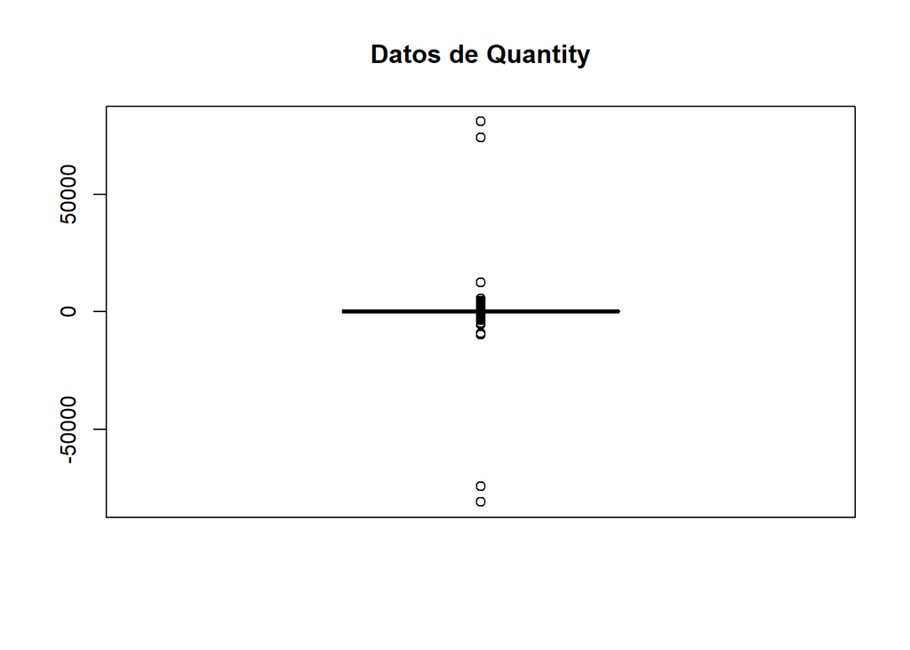

```r
boxplot(retail$Quantity,data=retail,main="Datos de Quantity")
```

De acuerdo con esto, existen 58619 valores “outliers”. Dado que representa un número importante de valores es importante validar estos datos con el experto del negocio a fin de comprender su validez y de no ser completamente correcto, será necesario imputarlos de alguna forma - sin embargo, hay que tener cuidado dado que puede alterar significativamente los resultados.

Podemos hacer el mismo estudio con el campo UnitPrice

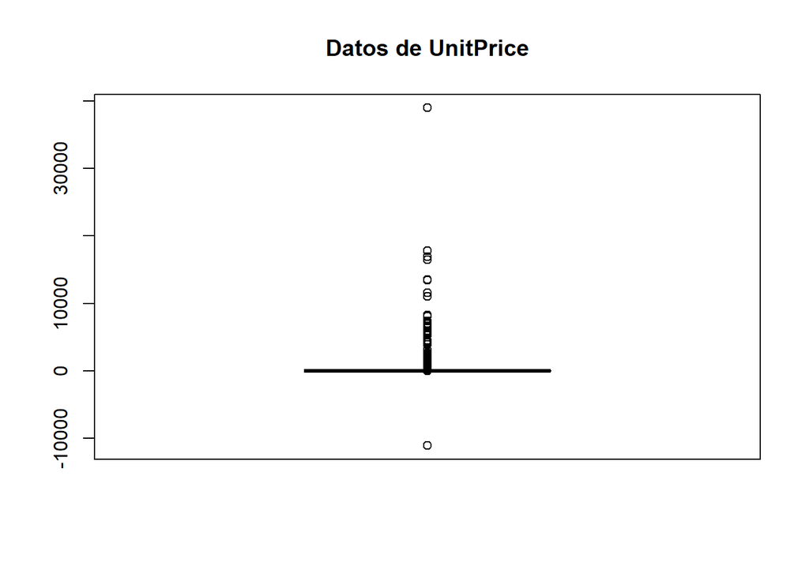

```r
boxplot(retail$UnitPrice,data=retail,main="Datos de UnitPrice")
```

De acuerdo con esto, existen 39627 valores “outliers” para UnitPrice. En este caso debemos hacer un tratamiento similar para los valores de la variable quantity.

Adicionalmente podemos revisar para los valores que representan montos de dinero (UnitPrice) o Cantidades, que los valores tengan sentido - podemos revisar por ejemplo que sean positivos:

Para Unit Price:

```r
UnitPrice_Positivos<- nrow(retail[retail$UnitPrice >= 0,])
UnitPrice_Positivos
```

```
## [1] 541907
```

```r
UnitPrice_Negativos<- nrow(retail[retail$UnitPrice < 0,])
UnitPrice_Negativos
```

```
## [1] 2
```

```r
kable(head(retail[retail$UnitPrice < 0,],10),"html", booktabs = T)%>%
  kable_styling(latex_options = "striped")
```

| InvoiceNo | StockCode | Description | Quantity | InvoiceDate | UnitPrice | CustomerID | Country | Total | InvoiceDay |
| --- | --- | --- | --- | --- | --- | --- | --- | --- | --- |
| A563186 | B | Adjust bad debt | 1 | 2011-08-12 14:51:00 | -11062.06 | NA | United Kingdom | -11062.06 | 2011-08-12 |
| A563187 | B | Adjust bad debt | 1 | 2011-08-12 14:52:00 | -11062.06 | NA | United Kingdom | -11062.06 | 2011-08-12 |

Podemos ver que solamente son dos valores negativos, y que por la descripcion que tienen, probablemente pueden ser ignorados.

Para Quantity:

```r
Quantity_Positivos<- nrow(retail[retail$Quantity >= 0,])
Quantity_Positivos
```

```
## [1] 531285
```

```r
Quantity_Negativos<- nrow(retail[retail$Quantity < 0,])
Quantity_Negativos
```

```
## [1] 10624
```

```r
kable(head(retail[retail$Quantity < 0,]),"html", booktabs = T)%>%
  kable_styling(latex_options = "striped")
```

| InvoiceNo | StockCode | Description | Quantity | InvoiceDate | UnitPrice | CustomerID | Country | Total | InvoiceDay |
| --- | --- | --- | --- | --- | --- | --- | --- | --- | --- |
| C536379 | D | Discount | -1 | 2010-12-01 09:41:00 | 27.50 | 14527 | United Kingdom | -27.50 | 2010-12-01 |
| C536383 | 35004C | SET OF 3 COLOURED FLYING DUCKS | -1 | 2010-12-01 09:49:00 | 4.65 | 15311 | United Kingdom | -4.65 | 2010-12-01 |
| C536391 | 22556 | PLASTERS IN TIN CIRCUS PARADE | -12 | 2010-12-01 10:24:00 | 1.65 | 17548 | United Kingdom | -19.80 | 2010-12-01 |
| C536391 | 21984 | PACK OF 12 PINK PAISLEY TISSUES | -24 | 2010-12-01 10:24:00 | 0.29 | 17548 | United Kingdom | -6.96 | 2010-12-01 |
| C536391 | 21983 | PACK OF 12 BLUE PAISLEY TISSUES | -24 | 2010-12-01 10:24:00 | 0.29 | 17548 | United Kingdom | -6.96 | 2010-12-01 |
| C536391 | 21980 | PACK OF 12 RED RETROSPOT TISSUES | -24 | 2010-12-01 10:24:00 | 0.29 | 17548 | United Kingdom | -6.96 | 2010-12-01 |

Para las cantidades se puede observar que son muchos mas, 10624. Es necesario revisar esto con los analistas del negocio. Sin embargo el hecho que una de las descripciones tenga el texto “Discount” nos hace pensar que tal vez sean por proceso de negocios - una forma de dar descuentos o de realizar devoluciones de productos.

# Fase de preparación de los datos

## Selección de datos:

### Selección de variables clave

- Quantity: Es la variable que nos indica cuales son las existencias que deben existir por cada producto para mejorar las existencias en inventarios basado en las ventas registradas.
- Unit Price: En conjunto con la variable quantity nos permite realizar el cálculo del valor monetario de las ventas realizadas por cliente.
- CustomerID: Nos permite agrupar las compras realizadas por el mismo cliente, esto con el fin de identificar cuáles son los mejores clientes de la compañía.
- Country: Nos permite analizar o agrupar el comportamiento de las compras por región.
- Total: Total es una variable derivada y nos permite obtener el monto total de las compras realizadas por cliente, para analizar cuales son los mejores clientes basados en las mismas.

Dado que el dataset solamente contiene 8 campos, no se descartará ninguna variable. Sin embargo si se evaluará descartar observaciones que presenten problemas como los outliers que se describen en la sección de Calidad de datos.